# MATH-2620_HW-03

## Problem 10

*In Problem 6.10, I generate a data set described by a 1,000 x 20 matrix* X *times arbitrary beta terms with some elements zero and others nonzero, plus a white noise error term. I split the data into a test set and training set and use best subset selection to create a model from the training set and test set. Finally, I create a plot comparing the estimated coefficients from the best subset selection to the true coefficients I used to generate the data. More of my comments are below.*

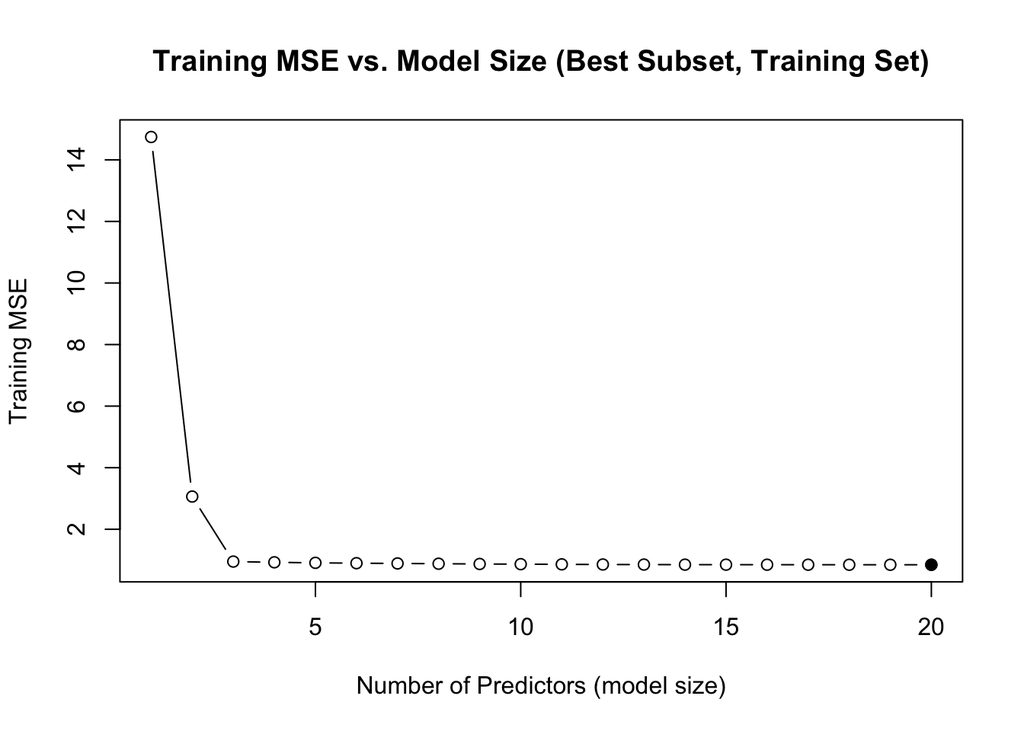

```r
### Part A ###
set.seed(10)
n = 1000
p = 20
X = matrix(rnorm(n * p), n, p)
beta = c(2, 3, 4, 0, 0, 0, 0, 0, 0, 0, 0, 0, 0, 0, 0, 0, 0, 0, 0, 0)
eps = rnorm(n)
Y = X %*% beta + eps

### Part B ###
set.seed(10)

train = sample(1:n, 100)
test = setdiff(1:n, train)

x.train = X[train, ]
x.test  = X[test, ]
y.train = Y[train]
y.test  = Y[test]

### Part C ###
train.df = as.data.frame(x.train)
names(train.df) = paste0("X", 1:ncol(train.df))
train.df$Y = y.train

regfit = regsubsets(Y ~ ., data = train.df, nvmax = p)
reg.sum = summary(regfit)

mse.train = reg.sum$rss / length(y.train)

plot(1:p, mse.train, type = "b",
     xlab = "Number of Predictors (model size)",
     ylab = "Training MSE",
     main = "Training MSE vs. Model Size (Best Subset, Training Set)")
points(which.min(mse.train), min(mse.train), pch = 19)
```

```r
which.min(mse.train) # Minimizing RSS, the best model uses all 20 predictors.
```

```
## [1] 20
```

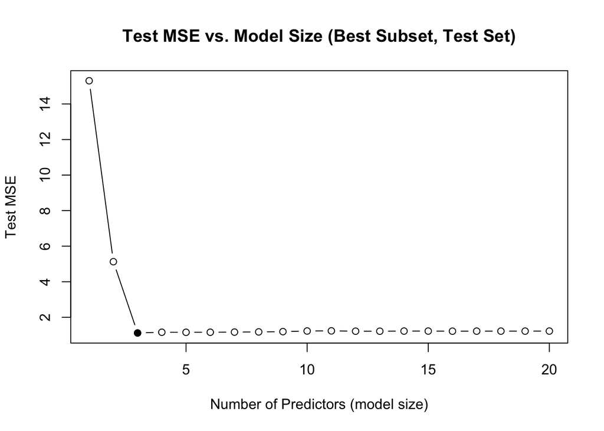

```r
### Part D ###
test.df = as.data.frame(x.test)
names(test.df) = paste0("X", 1:ncol(test.df))
test.df$Y = y.test

predict_regsubsets = function(object, newdata, id) {
  coefi = coef(object, id = id)
  mat   = model.matrix(Y ~ ., newdata)
  xvars = names(coefi)
  drop(mat[, xvars] %*% coefi)
}

mse.test = rep(NA_real_, p)
for (k in 1:p) {
  yhat = predict_regsubsets(regfit, newdata = test.df, id = k)
  mse.test[k] = mean((y.test - yhat)^2)
}

plot(1:p, mse.test, type = "b",
     xlab = "Number of Predictors (model size)",
     ylab = "Test MSE",
     main = "Test MSE vs. Model Size (Best Subset, Test Set)")
points(which.min(mse.test), min(mse.test), pch = 19)
```

```r
### Part E ###
which.min(mse.test)
```

```
## [1] 3
```

```r
min(mse.test)
```

```
## [1] 1.117129
```

```r
# A model with 3 predictors leads to the minimum value of the test set MSE.
# This reflects the actual model Y = 2X_1 + 3X_2 + 4X_3 + ε created at the beginning. The error is likely due to the sampling noise.

### Part F ###
# The selected model perfectly matches the true model size with 3 predictors. This means the best subset selection procedure correctly identified the model complexity that generalizes best.
best.k = 3
coef.best = coef(regfit, id = best.k)
coef.best
```

```
## (Intercept)          X1          X2          X3
##  0.07513025  1.78571824  3.00055522  3.87912033
```

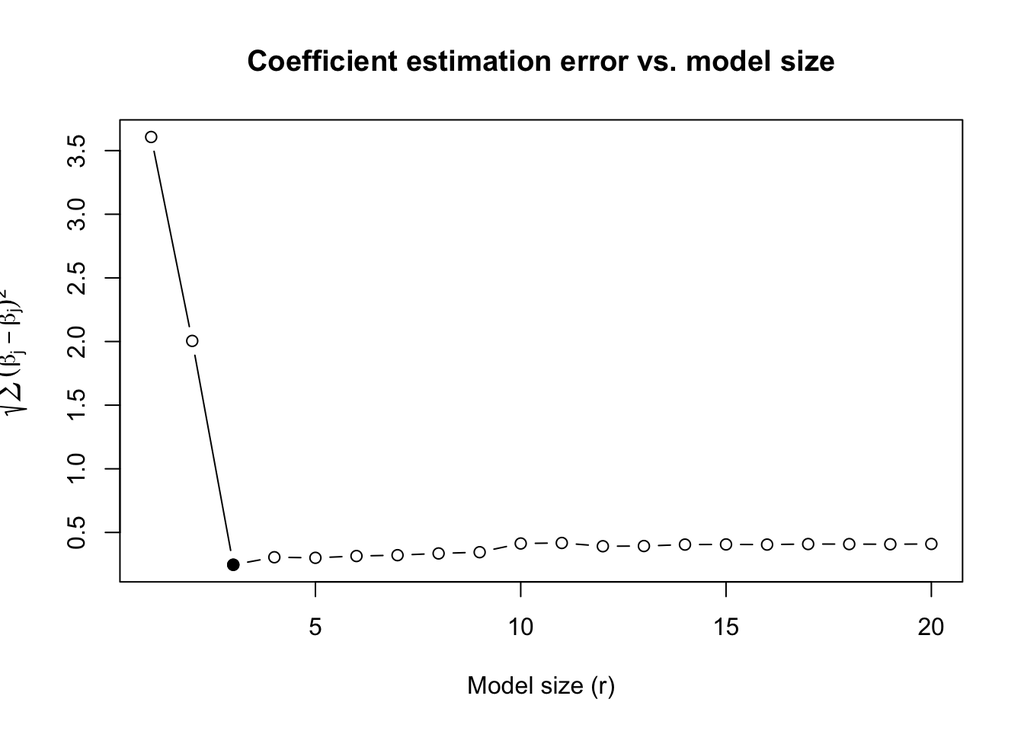

```r
# The estimated coefficient values match that of the model. The estimated model is Yhat = 0.07 + 1.8*X1 + 3*X2 + 3.9*X3, which is very close to Y = 2X_1 + 3X_2 + 4X_3 + ε. The differences are likely a result of the error distribution.
# Thus, the selected model at which the test set MSE is minimized is very true to the actual model.

### Part G ###
error.vec = rep(NA_real_, p)
for (r in 1:p) {
  beta.hat = rep(0, p)
  coef.r = coef(regfit, id = r)
  names.r = names(coef.r)[-1]
  beta.hat[as.numeric(sub("X", "", names.r))] = coef.r[-1]
  error.vec[r] = sqrt(sum((beta.hat - beta)^2))
}

plot(1:p, error.vec, type = "b",
     xlab = "Model size (r)",
     ylab = expression(sqrt(sum((hat(beta)[j]^r - beta[j])^2))),
     main = "Coefficient estimation error vs. model size")
points(which.min(error.vec), min(error.vec), pch = 19)
```

```r
# The coefficient-error plot reaches a minimum at r=3, which corresponds to the true model.
# As more predictors are added, the distance between estimated and true coefficients grows, just as the test MSE begins to rise.
# This plot looks very similar to the MSE plot from Part D. Thus, both plots support the observation that moderate model complexity yields the most accurate and stable estimates.
```